[figure not shown]

TPM(diag)-4

General Description

TIRE PRESSURE MONITORING SYSTEM (DIAGNOSTICS)

2. General Description

A: CAUTION

1. SUPPLEMENTAL RESTRAINT SYSTEM “AIRBAG”

Airbag system wiring harness is routed near the TPM control module.

CAUTION:

• Do not use electrical test equipment on any of the airbag system wiring harness circuits.

• Be careful not to damage the wiring harness of the airbag system when servicing the TPMS & key-

less entry CM or TPMS CM.

2. TPMS & KEYLESS ENTRY CM OR TPMS CM

• If the transmitter is replaced, ID registration for the transmitter is required. <Ref. to TPM(diag)-14, OPER-

ATION, Register Transmitter (ID).>

• When adjusting tire pressure indoors in winter, there is a big temperature difference between the indoor fa-

cilities and outside. Once the car is outside where the temperature is lower, the air pressure in the tires will

drop, causing the tire pressure warning light to illuminate, even if the pressure in the tires was adjusted to

standard values indoors. To avoid this, it is necessary to adjust the tire pressure to the high side in consid-

eration of the difference in temperature between inside and outside according to the following table.

• 235/45R17, 245/40R18

B: INSPECTION

Before performing diagnosis, check the following item which might affect the quality of the tire pressure mon-

itoring system.

1. TIRE

• Inspect that the tire pressure is within the specification while the tire is cool. (Refer to Tire Caution Label.)

• Check the tires for damage or the insertion of foreign matters.

2. BATTERY

Check that the amount of battery fluid, its specific gravity and voltage are within the specifications.

Standard voltage: 12 V or more

Specific gravity: 1.260 or more

Temperature

°C (°F)

Indoor temperature 15.5 (60)

Ambient temperature –1 (30) –12 (10) –23 (–10)

Air pressure

kPa (psi)

Front 250 (36) 265 (38) 280 (40)

Rear 240 (35) 255 (37) 270 (39)

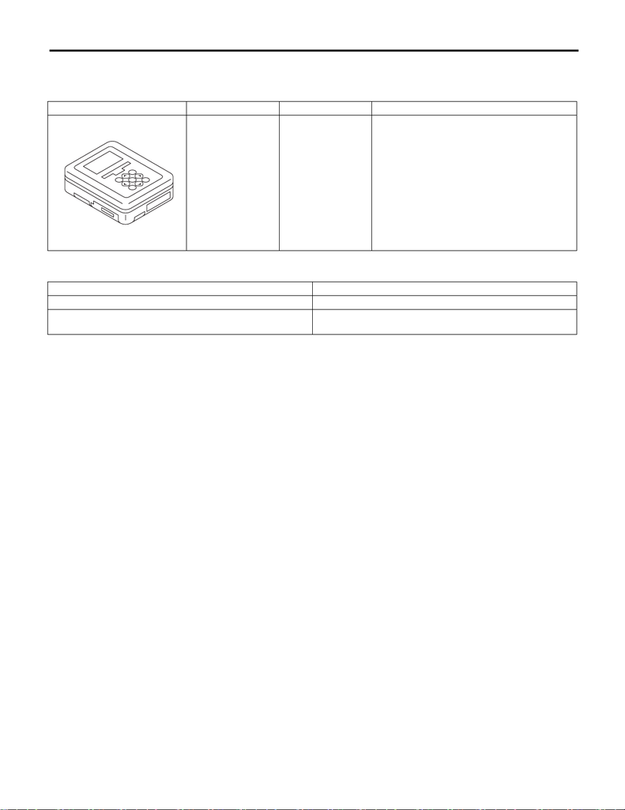

TPM(diag)-5

General Description

TIRE PRESSURE MONITORING SYSTEM (DIAGNOSTICS)

C: PREPARATION TOOL

1. SPECIAL TOOL

2. GENERAL TOOL

ILLUSTRATION TOOL NUMBER DESCRIPTION REMARKS

1B022XU0 SUBARU SELECT

MONITOR III KIT

Used for troubleshooting the electrical system.

TOOL NAME REMARKS

Circuit tester Used for measuring resistance, voltage and current.

Transmitter registration tool Used to register the transmitter ID.

Manufacturer: Kent-Moore Item number: J45295

ST1B022XU0